# Hans Rosling Convergence

Group 4

1/28/2020

# Convergence is defined in the dictionary as independent development of similar characters often associated with similarity of habits or environment. This is a valid conceptualization and widely accepted. Rosling would most likely have accepted the definition because he was looking at how GDP per capita affected countries throughout time.

```r
library(gapminder)
library(tidyverse)
library(ggridges)
```

#Motivation - Why do we care? Income inequality is a driving grievance in the international stage. Inequality tends to be a good indicator of likelihood of civil war if there are lootable resources available. Additionally, Rosling’s hypothesis is widely known and accepted. We wanted to test it using different data.

```r
gm_mod_lifeExp <-
  gapminder %>%
  group_by (year) %>%
  summarise (mean_lifeExp = mean(lifeExp),
            median_lifeExp = median(lifeExp),
            num_countries = n())

gm_mod_gdpPercap <-
  gapminder %>%
  group_by (year) %>%
  summarise (mean_gdpPercap = mean(gdpPercap),
            median_gdpPercap = median(gdpPercap),
            num_countries = n())

gm_mod<-
  gapminder%>%
  group_by (year)%>%
  summarise(median_lifeExp = median(lifeExp),
            median_gdpPercap = median(gdpPercap),
            num_countries = n())
```

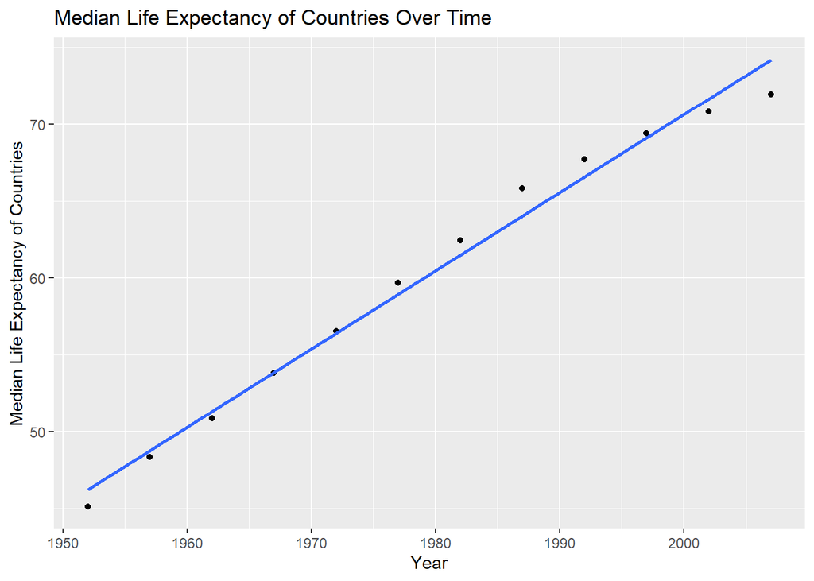

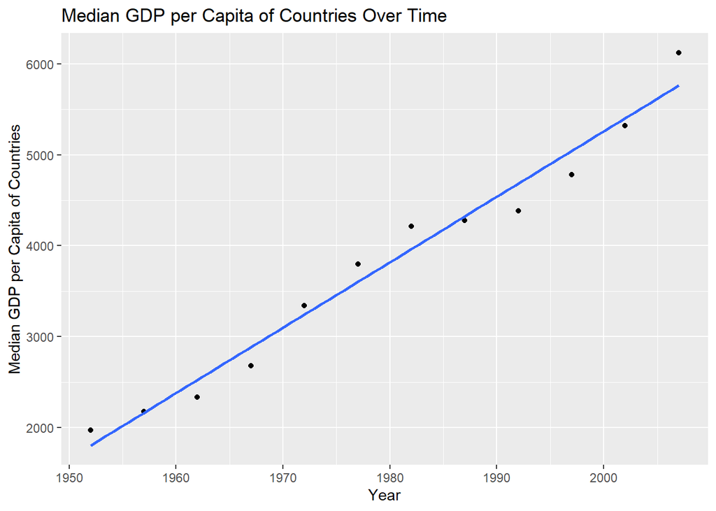

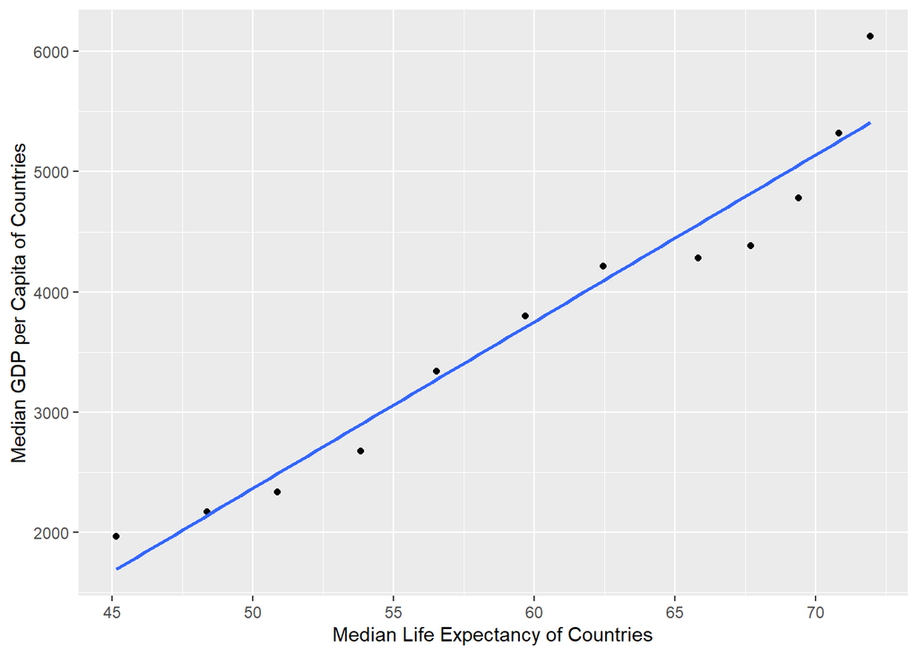

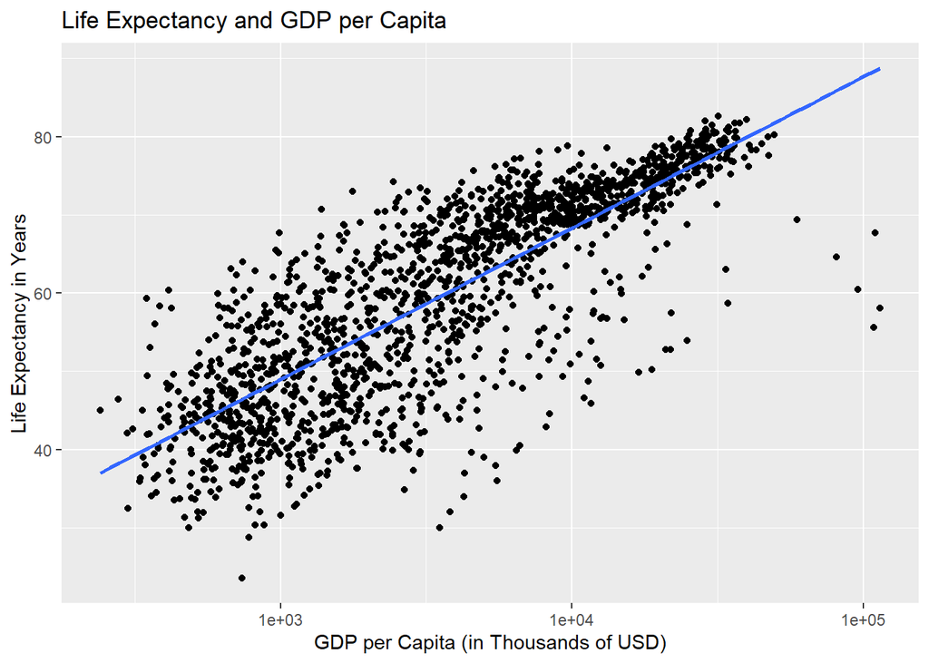

```r
ggplot(gapminder) +
  aes(x = gdpPercap) +
  aes(y = lifeExp) +
  geom_point() +
  geom_smooth(method = lm, se = F)+
    scale_x_log10()+
  labs (y = "Life Expectancy in Years", x= "GDP per Capita (in Thousands of USD)") +
  labs (title = "Life Expectancy and GDP per Capita")
```

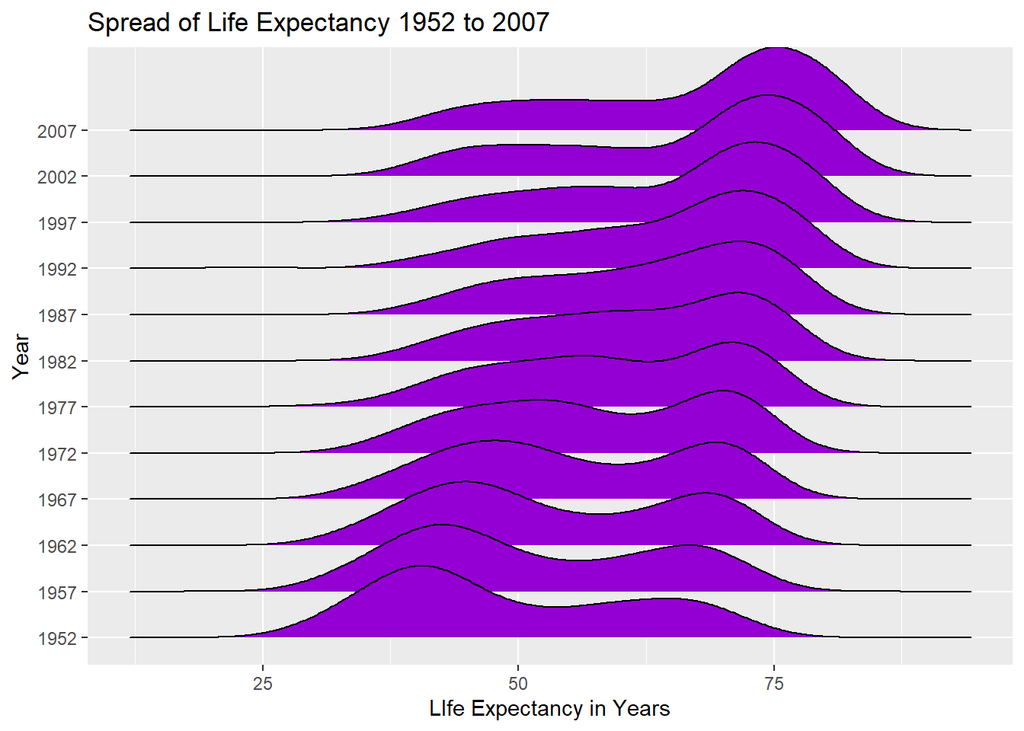

```r
ggplot(gapminder, aes(x = lifeExp, y = factor(year))) +
  geom_density_ridges(fill = "darkviolet") +
  labs(y = "Year", x = "LIfe Expectancy in Years") +
  labs( title = "Spread of Life Expectancy 1952 to 2007")
```

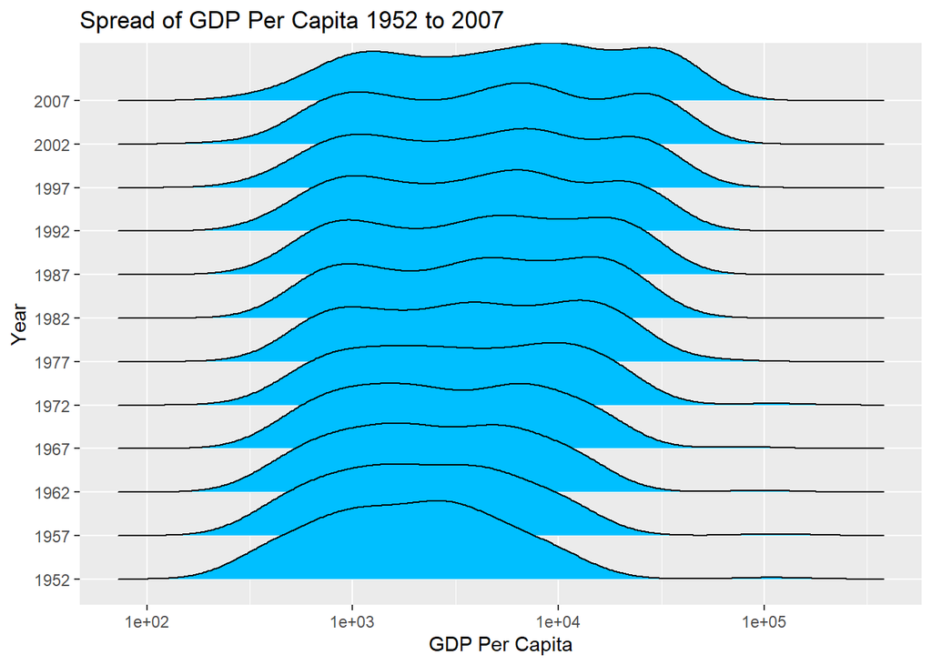

```r
ggplot(gapminder, aes(x = gdpPercap, y = factor(year))) +
  scale_x_log10()+
  geom_density_ridges(fill = "deepskyblue") +
  labs(y = "Year", x = "GDP Per Capita") +
  labs( title = "Spread of GDP Per Capita 1952 to 2007")
```

#Recommendations: #Further research would be to incorporate the SDI variables as it is a representation of development in addition to ecological impact associated with growth. This divides human development by a composite meteric of ecological impact that incorporates both key indicators or CO2 emissions per capita and material footprint per capita.

#GDP per capita was used, but it is an imperfect metric for looking at population wellbeing. This is because the wealthy people skew the data and overwhelms the data provided by more impoverished people.